# Methods and Supplemental Tables for Low cost conservation: Fisheries gear threats to marine species

Tim Cashion, Travis C. Tai, Vicky W.Y. Lam, Daniel Pauly, and U. Rashid Sumaila

Fri Oct 11 09:25:25 2019

## 0.1 Methods

### 0.1.1 IUCN data

The International Union for Conservation of Nature (IUCN) maintains the IUCN Red List of Threatened Species (hereafter, ‘Red List’) that documents the population status and threats of species globally. Species (and sub-populations of species) that are assessed by the IUCN are categorised into one of the following in order of increasing conservation threat: Least Concern, Near Threatened, Vulnerable, Endangered, Critically Endangered, and Extinct. A final category exists of ‘Data Deficient’ that indicates there is not enough information to properly assess the population status of a species. Together, Vulnerable, Endangered, and Critically Endangered are often grouped together as ‘Threatened’. In addition to the categorisation of the threat status, the IUCN provides species range maps, detailed description of threats, and other important information on the species included in the Red List.

We accessed spatial species distribution shape files from the Red List for comprehensively assessed groups that include marine organisms (*1*). We supplemented this with Bird Life International species distribution files for birds that occur in marine areas (*2*). Marine molluscs have not been comprehensively assessed (i.e., less than 80% of the species in this group have not been assessed) by the IUCN except for Cone Snails (*Conus* spp.), and this is a gap in our data coverage. We converted the species distribution maps to raster format at various spatial scales to correspond to existing datasets in fisheries research, but used a 0.5° by 0.5° for our analysis as it matches the *Sea Around Us* fisheries catch database. We rasterised the species distribution files following the same process of O’Hara (*3*).

We used the same prioritisation of species IUCN Categories based on regional assessments where possible as in O’Hara (*3*). Here, regional assessments were matched to associated (i.e., overlapping) marine ecoregions (*4*) that were then associated with their corresponding cells of the spatial grid used. Regional assessments were used in preference of global assessments where possible.

[interactive chart not shown]

Figure 1: Reason for elimination of species from our final analysis

### 0.1.2 Fisheries data

The *Sea Around Us* has reconstructed marine fisheries catches for all marine countries and territories from 1950 to present. The process of reconstruction supplements and corrects reported fisheries catches with estimates of known to be excluded fishing sectors (e.g., artisanal and recreational fishing) and practices (e.g., discarding) (*5*). These catches are spatially allocated according to a rule-based assignment and based on known information on where the fishery was operating (within domestic EEZs, foreign EEZs, the high seas, etc.). The spatial scale used is 0.5° by 0.5°.

The reconstructed catches were then assigned to their respective fishing gear types for industrial and small-scale sectors. This process relied on similar methods as the catch reconstructions relying on official catch statistics by gear type, as well as fisheries reports, catch surveys, newspaper articles, and other grey literature. The process by which each countries fishing gear was assigned is documented in Cashion (*6*, *7*). The result is a catch database with gear information included for all catches.

We used the *Sea Around Us* database (v.47) for catches by gear type (*7*, *8*) and were accessed from the *Sea Around Us* database by the first author. This database includes spatially allocated reconstructed fisheries catches by gear type and taxon for all fishing countries and territories of the world. The spatial scale of this dataset is 0.5° by 0.5° and has been used in many global fisheries studies (*9*, *10*).

In addition, we use the corollary Fisheries Economics Research Unit (FERU) ex-vessel price database that includes reported and estimated first-sale prices for all taxa for each fishing country by year (*11*) to incorporate the potential lost revenues for fisheries closures in areas of high biological importance. Revenue is calculated as the ex-vessel price (real 2010 USD per metric tonne) of a specific taxon caught by a country in a given year multiplied by its landings amount in metric tonnes.

Due to the importance of gear to our analysis, and its importance as a determinant on the ex-vessel price of fish (*12*–*14*), we modify the ex-vessel prices by a gear multiplier. We determine this gear multiplier through a hedonic pricing model where gear type is an explanatory variable of the ex-vessel fish price.

First, we combined two datasets that report fisheries ex-vessel revenues by gear type and species. The first is the U.S. National Marine Fisheries Service annual commercial landings by gear type (*15*). The second is the monthly landings by gear type, port and species of the UK’s fisheries (*16*). We harmonized the gear types listed in each to match our existing dataset gear types. While these two datasets are not representative of global fisheries nor ex-vessel prices for all species, they give adequate coverage to derive the effect of different gear types used for catching different species and how it modifies ex-vessel prices.

We then used a fixed-effects model with linear regression to derive the effect of changing gear type on the ex-vessel price $Price_{xyzt}$ for species $x$, gear $y$, in country $z$ in year $t$. We used the natural logarithm of landings and prices as these variables are closer to a normal distribution when log-transformed, and thus reduces potential heteroscedasticity in our residuals. We also use the country, species, and year as explanatory variables to account for other changes in the price both over time and between these different markets.

Our regression equation is:

$ln(Price_{xyzt}) = \beta_0 + \beta_1Gear_y + \beta_2ln(L_{xyzt}) + \beta_3Species_x + \beta_4Year_t + \beta_5Country_z$ (1)

We used the estimated gear-type coefficients as gear specific multipliers $\beta_1_{y}$ that will modify the ex-vessel price of fish caught (Table 4).

Finally, we used an updated version of FERU’s cost of fishing database (*17*) to account for the cost of fishing that varies by country and gear type. Cost of fishing is broken down into its component parts in the database (e.g., fuel, labour, capital, maintenance, etc.), and here we use the total cost by gear type and country per tonne of fish landed ($C_{yz}$). Where the cost of fishing was not available for a particular gear and country, we used the regional average for that gear type, and where this was not possible we used the average cost across gear types for the region. We used the FAO socioeconomic regions for this stage of the analysis. We then derive the profit by gear type and country for each cell $i$ , based on the catch by gear type multiplied by the ex-vessel price multiplied by the gear type multiplier ($M_{y}$) minus the cost of fishing for that amount of landings. Therefore, profit (*P*) in cell *i* is equal to:

$P_{i} = \sum_{x=1}^{x} (L_{xyi} * P_{x} * M_{y}) - (L_{xyi} * C_{y})$ (2)

Both catch and profits are expressed throughout in tonnes/km<sup>2</sup> and $/km<sup>2</sup> calculated based on the water area in each 0.5° by 0.5° cell.

Our analysis focuses on the trade-offs among different fisheries with specific gear types. As such, we did not use the Global Fishing Watch data where gear types are often aggregated (bottom and pelagic trawlers grouped together as trawlers), or only represent a narrow subset of the fleet (e.g., drifting longlines instead of all longlines) (*18*). While the Global Fishing Watch data covers a large part of the global catch (perhaps near 75% in recent years), it does not have the same coverage of vessels. The dataset is biased against small-scale vessels which are not harm-free.

### 0.1.3 Analysis

We aim to map areas of high fisheries interest and high conservation concern. The areas with high overlap between conservation concern but low fisheries catches and effort are areas that could be fully protected from these threats for the long term (termed here, ‘easy wins’). However, the areas with high overlap of fisheries interest and high conservation concern are where the impacts on species may be greatest both in terms of fisheries threats and the potential benefits for conservation from fisheries closures.

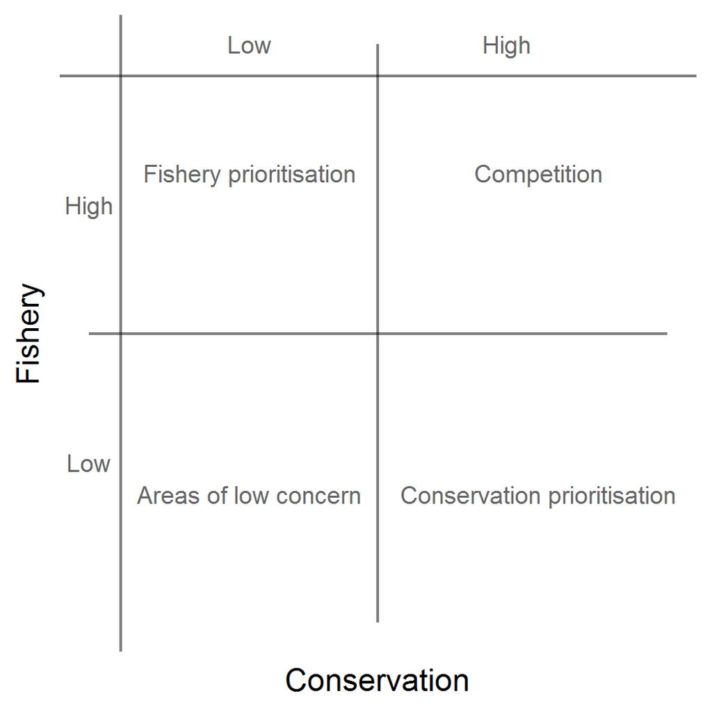

Figure 2: Theoretical basis for competition between fisheries and conservation

$Biodiversity Risk Score_{cell} = \frac{1}{N_{cell}}\sum_{i=1}^{N_{cell}}s_{i}$ (3)

Where $N$ is number of assessed species in the $cell$ , $s_{i}$ is the conservation status ($s$) of species ($i$). All biodiversity risk scores are thus values of 0-1 that roughly correspond to the linear IUCN Category scale described above (Table 1).

Second, we adapt this metric so that it isn’t normalised to the mean threat in the cell but representative of scale (number of species) and severity (IUCN Category) of threat. This metric is named the weighted threat score defined as the sum of species present multiplied by their threat category numeric score, but is not divided by the number of species in a given cell. We do not normalise by this to highlight areas of conservation concern based on the number of species in that cell in addition to their threat status.

$WeightedThreatScore_{i,g} = \sum_{i=1}^{N_{cell}}s_{i}$ (4)

This analysis was conducted in R (*19*), and used the tidyverse (*20*), rMarkdown (*21*), tidytext (*22*); gridExtra (*23*); sf (*24*), rgdal (*25*), cowplot (*26*), and wesanderson (*27*) packages. All code and outputs are available at www.github.com/timcashion/iucnfishingthreats.

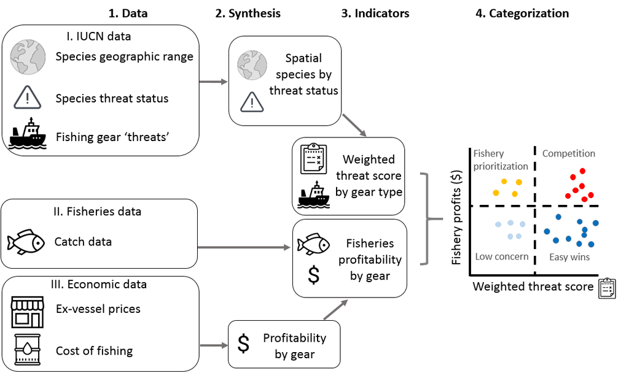

Figure 3. Conceptual methods figure.

## 0.2 Supplemental Tables

Table S1.

Table 1: Weighting of IUCN Categories

| Former code | Category | Current Code | Category Score |
| --- | --- | --- | --- |
| VU | Vulnerable | VU | 0.4 |
| V | Vulnerable | VU | 0.4 |
| CR | Critically Endangered | CR | 0.8 |
| EN | Endangered | EN | 0.6 |
| E | Endangered | EN | 0.6 |
| NT | Near Threatened | NT | 0.2 |
| LC | Least Concern | LC | 0.0 |
| LR/nt | Lower Risk/near threatened | NT | 0.2 |
| LR/lc | Lower Risk/least concern | LC | 0.0 |
| DD | Data Deficient | DD | NA |
| R | Rare | EN | 0.6 |
| O | Out of Danger | LC | 0.0 |
| NA | “Very rare but believed to be stable or increasing” | CR | 0.8 |
| NA | “Status inadequately known-survey required or data sought” | DD | NA |
| LR/cd | Lower Risk/conservation dependent | VU | 0.4 |
| K | Insufficiently Known | DD | NA |
| NA | “Very rare and believed to be decreasing in numbers” | CR | 0.8 |
| NA | “Less rare but believed to be threatened-requires watching” | EN | 0.6 |
| I | Indeterminate | DD | NA |
| EW | Extinct in the Wild | EX | 1.0 |
| EX | Extinct | EX | 1.0 |
| Ex | Extinct | EX | 1.0 |
| NE | Not Evaluated | NE | NA |
| N.E. | Not Evaluated | NE | NA |
| T | Threatened | EN | 0.6 |
| NR | Not Recognized | DD | NA |

Table S2.

Table 2: Search terms used for identifying gear types in IUCN narrative text.

| Gear type | Search terms |
| --- | --- |
| Bottom trawl | bottom trawl\|deepwater trawl\|demersal trawl\|prawn trawl\|benthic trawl\|otter trawl\|beam trawl\|shrimp trawl |
| Pelagic trawl | pelagic trawl\|shallow trawl\|midwater trawl\|surface trawl |
| Trawl | trawl\|trawling |
| Longlines | longline\|hooks |
| Lines | hook and line\|hook and\|and line\|hook\|line\|pole and\|jig\|hand line |
| Nets | net |
| Seines | seine\|purse\|encircling |
| Gillnets | gill net\|gillnet\|entangl\|entangle |
| Dredges | dredge\|drag |
| Traps | pot\|trap\|fyke |
| Drifting longlines | drifting longlines\|drifting lines |
| Squid jiggers | jig\|squid jiggers\|jiggers\|squid jigging\|jigging |
| Small scale | small scale\|artisanal\|subsistence\|small-scale |
| Others | harpoon\|bagnets\|bag\|spear |

Table S3.

Table 3: Gear types identified in the *Sea Around Us* database.

| Gear type | Super code |
| --- | --- |
| Bottom trawl | Bottom trawl |
| Shrimp trawl | Bottom trawl |
| Beam trawl | Bottom trawl |
| Otter trawl | Bottom trawl |
| Pelagic trawl | Pelagic trawl |
| Lines | Longline |
| Pole and line | Longline |
| Longline | Longline |
| Hand lines | Longline |
| Encircling nets | Purse seine |
| Purse seine | Purse seine |
| Small encircling nets | Purse seine |
| Gillnet | Gillnet |
| Trammel nets | Gillnet |
| Other | Other |
| Pots or traps | Other |
| Other nets | Other |
| Dredge | Other |
| Hand or tools | Other |
| Dragged gear | Other |
| Mixed gear | Other |
| Artisanal fishing gear | Small scale |
| Long distance small scale | Small scale |
| Recreational fishing gear | Small scale |
| Subsistence fishing gear | Small scale |
| Cast nets | Small scale |
| Bagnets | Small scale |
| Harpoon | Small scale |
| Hand or tools | Small scale |
| Small scale seine nets | Small scale |
| Small scale encircling nets | Small scale |
| Small scale trammel net | Small scale |
| Small scale gillnets | Small scale |
| Small scale other nets | Small scale |
| Small scale pots or traps | Small scale |
| Small scale lines | Small scale |
| Small scale hand lines | Small scale |
| Small scale pole lines | Small scale |
| Small scale longline | Small scale |
| Small scale purse seine | Small scale |
| Unknown class | Unknown |
| Unknown by source | Unknown |
| Unknown by author | Unknown |

Table S4.

Table 4: Regression results for gear types used and their gear multipliers used

| Super_code | Estimate | Std.error | Statistic | P.value | Multiplier_mean | Multiplier_ll | Multiplier_ul |
| --- | --- | --- | --- | --- | --- | --- | --- |
| Gillnet | 0.155 | 0.002 | 72.594 | *** | 1.168 | 1.164 | 1.172 |
| Longline | 0.202 | 0.003 | 57.857 | *** | 1.224 | 1.217 | 1.230 |
| Other | 0.039 | 0.004 | 10.007 | *** | 1.039 | 1.032 | 1.047 |
| Pelagic trawl | -0.856 | 0.059 | -14.606 | *** | 0.425 | 0.310 | 0.540 |
| Pots and traps | 0.227 | 0.003 | 78.490 | *** | 1.255 | 1.250 | 1.261 |
| Purse seine | -0.209 | 0.015 | -14.064 | *** | 0.812 | 0.783 | 0.841 |
| Small scale | 0.409 | 0.014 | 29.904 | *** | 1.505 | 1.478 | 1.532 |
| Bottom trawl | 0.000 | 0.000 | 0.000 | Not Estimated | 1.000 | 1.000 | 1.000 |
| Unknown | 0.000 | 0.000 | 0.000 | Not Estimated | 1.000 | 1.000 | 1.000 |

Table S5

Table 5: Area of high seas by categorization

| Category | Water Area (million km2) | Proportion of High Seas (%) |
| --- | --- | --- |
| Fishery competition | 452.90 | 15.98 |
| Fishery prioritization | 111.86 | 3.95 |
| Area of low concern | 1467.00 | 51.78 |
| Easy wins | 801.56 | 28.29 |

1. IUCN, IUCN Red List of Threatened Species. Version 2019-1 (2019), (available at www.iucnredlist.org).

2. BirdLife International, Handbook of the Birds of the World, No Title (2018), (available at http://datazone.birdlife.org/species/requestdis).

3. C. C. O’Hara, J. Carlos Villaseñor-Derbez, G. M. Ralph, B. S. Halpern, Mapping status and conservation of global at-risk marine biodiversity. *Conservation Letters* (2019), doi:10.1111/conl.12651.

4. M. D. Spalding, H. E. Fox, G. R. Allen, N. Davidson, Z. A. Ferdaña, M. Finlayson, B. S. Halpern, M. A. Jorge, A. Lombana, S. A. Lourie, K. D. Martin, E. McManus, J. Molnar, C. A. Recchia, J. Robertson, Marine Ecoregions of the World: A Bioregionalization of Coastal and Shelf Areas. *BioScience* (2007), doi:10.1641/b570707.

5. D. Zeller, M.-L. Palomares, A. Tavakolie, M. Ang, D. Belhabib, W. W. L. Cheung, V. W. Lam, E. Sy, G. Tsui, K. Zylich, D. Pauly, Still catching attention: Sea Around Us reconstructed global catch data, their spatial expression and public accessibility. *Marine Policy*. **70**, 145–152 (2016).

6. T. Cashion, D. Al-Abdulrazzak, D. Belhabib, B. Derrick, E. Divovich, D. Moutopoulos, S. L. Noël, M.-L. Palomares, L. C. Teh, D. Zeller, D. Pauly, “A global fishing gear dataset for integration into the Sea Around Us global fisheries databases” (1, Institute for the Oceans; Fisheries, Vancouver, 2018), p. 71.

7. T. Cashion, D. Al-abdulrazzak, D. Belhabib, B. Derrick, E. Divovich, D. K. Moutopoulos, S.-l. Noël, M. L. D. Palomares, L. C. L. Teh, D. Zeller, D. Pauly, Reconstructing global marine fishing gear use: Catches and landed values by gear type and sector. *Fisheries Research*. **206**, 57–64 (2018).

8. D. Pauly, D. Zeller, Eds., *Sea Around Us Concepts, Design and Data (seaaroundus.org)* (2015).

9. D. Grémillet, A. Ponchon, M. Paleczny, M. L. D. Palomares, V. Karpouzi, D. Pauly, Persisting Worldwide Seabird-Fishery Competition Despite Seabird Community Decline. *Current Biology*. **28**, 4009–4013.e2 (2018).

10. L. Schiller, M. Bailey, J. Jacquet, E. Sala, “High seas fisheries play a negligible role in addressing global food security” (2018), pp. 8351–8359.

11. T. C. Tai, T. Cashion, V. W. Y. Lam, W. Swartz, U. R. Sumaila, Ex-vessel fish price database: disaggregating prices for low-priced species from reduction fisheries. *Frontiers in Marine Science*. **4**, 1–10 (2017).

12. M.-y. Lee, Hedonic Pricing of Atlantic Cod: Effects of Size, Freshness, and Gear. *Marine Resource Economics*. **29** (2014).

13. F. Asche, J. Guillen, The importance of fishing method , gear and origin: The Spanish hake market. *Marine Policy*. **36**, 365–369 (2012).

14. K. E. Mcconnell, I. E. Strand, Hedonic Prices for Fish : Tuna Prices in Hawaii. *American Journal of Agricultural Economics*. **82**, 133–144 (2000).

15. NMFS, Commercial Fisheries - Annual Landings (2017), (available at http://www.st.nmfs.noaa.gov/commercial-fisheries/commercial-landings/annual-landings/index).

16. Marine Management Organisation, UK fleet landings and foreign fleet landings into the UK by port (2017), (available at https://www.gov.uk/government/statistical-data-sets/uk-fleet-landings-and-foreign-fleet-landings-into-the-uk-by-port).

17. V. Lam, U. R. Sumaila, A. Dyck, D. Pauly, R. Watson, Construction and first applications of a global cost of fishing database. *ICES Journal of Marine Science*. **68**, 1996–2004 (2011).

18. D. A. Kroodsma, J. Mayorga, T. Hochberg, N. A. Miller, K. Boerder, F. Ferretti, A. Wilson, B. Bergman, T. D. White, B. A. Block, P. Woods, B. Sullivan, C. Costello, B. Worm, Tracking the global footprint of fisheries. *Science (New York, N.Y.)*. **359**, 904–908 (2018).

19. R Core Team, R Development Core Team. **55** (2017), pp. 275–286.

20. H. Wickham, “tidyverse: Easily Install and Load ’Tidyverse’ Packages.” (2016), (available at https://cran.r-project.org/package=tidyverse).

21. B. Baumer, D. Udwin, R Markdown (2015),, doi:10.1002/wics.1348.

22. C. Fay, Text Mining with R : A Tidy Approach. *Journal of Statistical Software* (2018), doi:10.18637/jss.v083.b01.

23. B. Auguie, Package ‘ gridExtra ’. *R CRAN Project* (2017).

24. E. Pebesma, Simple Features for R: Standardized Support for Spatial Vector Data. *The R Journal* (2019), doi:10.32614/rj-2018-009.

25. E. Pebesma, B. Rowlingson, R. Bivand, Package ‘ rgdal ’. *R-CRAN* (2012).

26. Huber, W., Carey, V. J., Gentleman, R., Anders, S., Carlson, M., Carvalho, B. S., Bravo, H. C., Davis, S., Gatto, L., Girke, T., Gottardo, R., Hahne, F., Hansen, K. D., Irizarry, R. A., Lawrence, M., Love, M. I., MacDonald, J., Obenchain, V., Ole’s, A. K., Pag‘es, H., Reyes, A., Shannon, P., Smyth, G. K., Tenenbaum, D., Waldron, L., Morgan, M., C. O. Wilke, H. Wickham, R Core Team, cowplot: Streamlined Plot Theme and Plot Annotations for ’ggplot2’. *Nature Methods* (2017).

27. K. Ram, H. Wickham, wesanderson: A Wes Anderson Palette Generator (2018), (available at https://cran.r-project.org/package=wesanderson).